# Practical Lab 3 - Vanilla CNN and Fine-Tune VGG16 - for Dogs and Cats Classification

#### Jun He(8903073) due:2024-12-01

**notice: model didn't run completely.**

## In this lab, we will work through a common practice of Deep Learning Engineers - that is - take an existing model, that does something similar to what the engineer is interested doing, and fine-tune it for the specific task at-hand.

1. Obtain the Data: Get the Dogs vs Cats dataset (see class' notebook, only 5000, not 25,000, images are required, these image set is defined in the notebook)
2. EDA: Explore the data with relevant graphs, statistics and insights (5 points)
3. Train two networks (use callbacks to save the best model version):

Define a Neural Network of your choice (3 points) Fine-Tune VGG16 (pre-trained on imagenet). Make sure to use validation to test for over-fitting. Plot the appropriate graph (3 points) 4. Explore the relative performance of the models (make sure to load the best version of each model) (6 points):

- accuracy
- confusion metric
- precision, recall, F1-score,
- precision-recall curve.
- Explore specific examples in which the model failed to predict correctly.
5. Add your conclusions. (3 point)

```python
from tensorflow import keras
from tensorflow.keras import layers
import pathlib
from tensorflow.keras.utils import image_dataset_from_directory
import matplotlib.pyplot as plt
```

### Step1:Obtain the Data

The dataset can be obtained from:

- [Dogs versus Cats](https://www.kaggle.com/c/dogs-vs-cats) - The Kaggle competition
- [The Dataset](https://www.kaggle.com/datasets/biaiscience/dogs-vs-cats) (with an Open Data license)

```python
# This should point to the small dataset of the Kaggle Dogs vs Cats competition that was created in a previous notebook
data_folder = pathlib.Path('./data/kaggle_dogs_vs_cats_small')
```

```python
train_dataset = image_dataset_from_directory(
    data_folder / "train",
    image_size=(180, 180),
    batch_size=32)
validation_dataset = image_dataset_from_directory(
    data_folder / "validation",
    image_size=(180, 180),
    batch_size=32)
test_dataset = image_dataset_from_directory(
    data_folder / "test",
    image_size=(180, 180),
    batch_size=32)
```

```
Found 2000 files belonging to 2 classes.
Found 1000 files belonging to 2 classes.
Found 2000 files belonging to 2 classes.
```

### Step2:EDA

```
Classes: ['cat', 'dog']
```

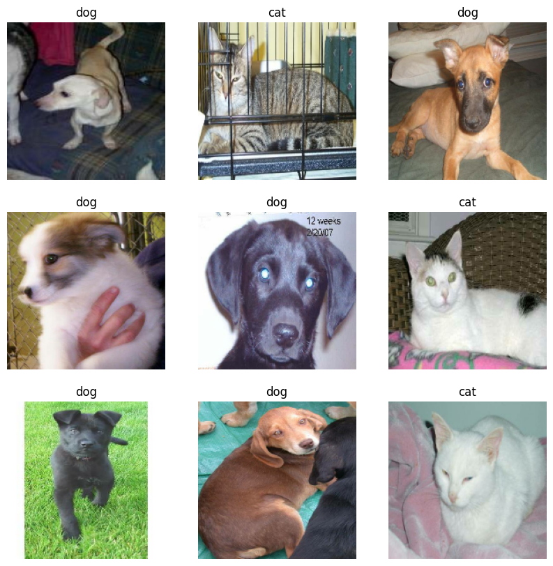

```python
class_names = train_dataset.class_names
print("Classes:", class_names)

# Visualize some images from the training set
plt.figure(figsize=(10, 10))
for images, labels in train_dataset.take(1):
    for i in range(9):
        ax = plt.subplot(3, 3, i + 1)
        plt.imshow(images[i].numpy().astype("uint8"))
        plt.title(class_names[labels[i]])
        plt.axis("off")
```

**Statistics**

1. Check image dimensions, pixel values, and aspect ratios for consistency.
2. Explore augmentation strategies to improve model robustness.

```python
for image_batch, label_batch in train_dataset.take(1):
    print("Image batch shape:", image_batch.shape)
    print("Label batch shape:", label_batch.shape)
```

```
Image batch shape: (32, 180, 180, 3)
Label batch shape: (32,)
```

```python
# Data augmentation
data_augmentation = keras.Sequential(
    [
      layers.RandomFlip("horizontal"),
      layers.RandomRotation(0.1),
      layers.RandomZoom(0.2),
    ]
)
```

### Step3:Train two networks

### 3-1 CNN model training

```python
def create_vanilla_cnn_model():
  inputs = keras.Input(shape=(180, 180, 3))
  x = data_augmentation(inputs)

  x = layers.Rescaling(1.0 / 255)(x)

  x = layers.Conv2D(filters=32, kernel_size=3, activation="relu")(x)
  x = layers.MaxPooling2D(pool_size=2)(x)

  x = layers.Conv2D(filters=64, kernel_size=3, activation="relu")(x)
  x = layers.MaxPooling2D(pool_size=2)(x)

  x = layers.Conv2D(filters=128, kernel_size=3, activation="relu")(x)
  x = layers.MaxPooling2D(pool_size=2)(x)

  x = layers.Conv2D(filters=256, kernel_size=3, activation="relu")(x)
  x = layers.MaxPooling2D(pool_size=2)(x)

  x = layers.Conv2D(filters=256, kernel_size=3, activation="relu")(x)
  x = layers.Flatten()(x)

  x = layers.Dense(256, activation="relu")(x)

  x = layers.Dropout(0.5)(x)
  outputs = layers.Dense(1, activation="sigmoid")(x)

  model = keras.Model(inputs=inputs, outputs=outputs)

  model.compile(loss="binary_crossentropy", optimizer="rmsprop", metrics=["accuracy"])

  return model
```

```python
vanilla_cnn_model = create_vanilla_cnn_model()
vanilla_cnn_model.summary()
```

```
Model: "model"
_________________________________________________________________
 Layer (type)                Output Shape              Param #
=================================================================
 input_1 (InputLayer)        [(None, 180, 180, 3)]     0

 sequential (Sequential)     (None, 180, 180, 3)       0

 rescaling (Rescaling)       (None, 180, 180, 3)       0

 conv2d (Conv2D)             (None, 178, 178, 32)      896

 max_pooling2d (MaxPooling2D  (None, 89, 89, 32)       0
 )

 conv2d_1 (Conv2D)           (None, 87, 87, 64)        18496

 max_pooling2d_1 (MaxPooling  (None, 43, 43, 64)       0
 2D)

 conv2d_2 (Conv2D)           (None, 41, 41, 128)       73856

 max_pooling2d_2 (MaxPooling  (None, 20, 20, 128)      0
 2D)

 conv2d_3 (Conv2D)           (None, 18, 18, 256)       295168

 max_pooling2d_3 (MaxPooling  (None, 9, 9, 256)        0
 2D)

 conv2d_4 (Conv2D)           (None, 7, 7, 256)         590080

 flatten (Flatten)           (None, 12544)             0

 dense (Dense)               (None, 256)               3211520

 dropout (Dropout)           (None, 256)               0

 dense_1 (Dense)             (None, 1)                 257

=================================================================
Total params: 4,190,273
Trainable params: 4,190,273
Non-trainable params: 0
_________________________________________________________________
```

```python
CNN_callbacks = [
  keras.callbacks.ModelCheckpoint(
      filepath="./models/vanilla_cnn_model.h5",
      save_best_only=True,
      monitor="val_loss",
  )
]

CNN_history = vanilla_cnn_model.fit(
    train_dataset,
    epochs=100,
    validation_data=validation_dataset,
    callbacks=CNN_callbacks,
)
```

```python
# Displaying curves of loss and accuracy during training
accuracy = CNN_history.history["accuracy"]
val_accuracy = CNN_history.history["val_accuracy"]
loss = CNN_history.history["loss"]
val_loss = CNN_history.history["val_loss"]
epochs = range(1, len(accuracy) + 1)
plt.plot(epochs, accuracy, "bo", label="Training accuracy")
plt.plot(epochs, val_accuracy, "b", label="Validation accuracy")
plt.title("Training and validation accuracy")
plt.legend()
plt.figure()
plt.plot(epochs, loss, "bo", label="Training loss")
plt.plot(epochs, val_loss, "b", label="Validation loss")
plt.title("Training and validation loss")
plt.legend()
plt.show()
```

[output not shown]

### 3-2 Fine-tuning VGG16 model

```python
conv_base = keras.applications.vgg16.VGG16(
    weights="imagenet",
    include_top=False,
    input_shape=(180, 180, 3))
```

```python
conv_base.summary()
```

```
Model: "vgg16"
_________________________________________________________________
 Layer (type)                Output Shape              Param #
=================================================================
 input_2 (InputLayer)        [(None, 180, 180, 3)]     0

 block1_conv1 (Conv2D)       (None, 180, 180, 64)      1792

 block1_conv2 (Conv2D)       (None, 180, 180, 64)      36928

 block1_pool (MaxPooling2D)  (None, 90, 90, 64)        0

 block2_conv1 (Conv2D)       (None, 90, 90, 128)       73856

 block2_conv2 (Conv2D)       (None, 90, 90, 128)       147584

 block2_pool (MaxPooling2D)  (None, 45, 45, 128)       0

 block3_conv1 (Conv2D)       (None, 45, 45, 256)       295168

 block3_conv2 (Conv2D)       (None, 45, 45, 256)       590080

 block3_conv3 (Conv2D)       (None, 45, 45, 256)       590080

 block3_pool (MaxPooling2D)  (None, 22, 22, 256)       0

 block4_conv1 (Conv2D)       (None, 22, 22, 512)       1180160

 block4_conv2 (Conv2D)       (None, 22, 22, 512)       2359808

 block4_conv3 (Conv2D)       (None, 22, 22, 512)       2359808

 block4_pool (MaxPooling2D)  (None, 11, 11, 512)       0

 block5_conv1 (Conv2D)       (None, 11, 11, 512)       2359808

 block5_conv2 (Conv2D)       (None, 11, 11, 512)       2359808

 block5_conv3 (Conv2D)       (None, 11, 11, 512)       2359808

 block5_pool (MaxPooling2D)  (None, 5, 5, 512)         0

=================================================================
Total params: 14,714,688
Trainable params: 14,714,688
Non-trainable params: 0
_________________________________________________________________
```

```python
# new model using VGG16 as the base, freezing all layers except the top four layers
conv_base.trainable = True
for layer in conv_base.layers[:-4]:
    layer.trainable = False

inputs = keras.Input(shape=(180, 180, 3))
x = data_augmentation(inputs)
x = keras.applications.vgg16.preprocess_input(x)
x = conv_base(x)

x = layers.Flatten()(x)
x = layers.Dense(256, activation="relu")(x)
x = layers.Dropout(0.5)(x)
outputs = layers.Dense(1, activation="sigmoid")(x)

model = keras.Model(inputs=inputs, outputs=outputs)

model.compile(loss="binary_crossentropy", optimizer=keras.optimizers.RMSprop(learning_rate=1e-5),
                metrics=["accuracy"])
model.summary()
```

```
Model: "model_1"
_________________________________________________________________
 Layer (type)                Output Shape              Param #
=================================================================
 input_3 (InputLayer)        [(None, 180, 180, 3)]     0

 sequential (Sequential)     (None, 180, 180, 3)       0

 tf.__operators__.getitem (S  (None, 180, 180, 3)      0
 licingOpLambda)

 tf.nn.bias_add (TFOpLambda)  (None, 180, 180, 3)      0

 vgg16 (Functional)          (None, 5, 5, 512)         14714688

 flatten_1 (Flatten)         (None, 12800)             0

 dense_2 (Dense)             (None, 256)               3277056

 dropout_1 (Dropout)         (None, 256)               0

 dense_3 (Dense)             (None, 1)                 257

=================================================================
Total params: 17,992,001
Trainable params: 10,356,737
Non-trainable params: 7,635,264
_________________________________________________________________
```

```python
#Train the fine-tuned VGG16 model.

finetuned_callbacks = [
  keras.callbacks.ModelCheckpoint(
      filepath="./models/finetuned_vgg16_model.h5",
      save_best_only=True,
      monitor="val_loss",
  )
]

finetuned_history = model.fit(
    train_dataset,
    epochs=50,
    validation_data=validation_dataset,
    callbacks=finetuned_callbacks,
)
```

```python
# plot the results
import matplotlib.pyplot as plt
acc = finetuned_history.history["accuracy"]
val_acc = finetuned_history.history["val_accuracy"]
loss = finetuned_history.history["loss"]
val_loss = finetuned_history.history["val_loss"]
epochs = range(1, len(acc) + 1)
plt.plot(epochs, acc, "bo", label="Training accuracy")
plt.plot(epochs, val_acc, "b", label="Validation accuracy")
plt.title("Training and validation accuracy")
plt.legend()
plt.figure()
plt.plot(epochs, loss, "bo", label="Training loss")
plt.plot(epochs, val_loss, "b", label="Validation loss")
plt.title("Training and validation loss")
plt.legend()
plt.show()
```

[output not shown]

### Step4:Explore the relative performance of the models

#### Load the Best Model Checkpoints

```python
from tensorflow.keras.models import load_model

vanilla_cnn_model = load_model("./models/vanilla_cnn_model.h5")
finetuned_vgg16_model = load_model("./models/finetuned_vgg16_model.h5")
```

### Evaluate Performance Metrics:

- Calculate accuracy, precision, recall, F1-score, and plot a confusion matrix for both models.

```
Vanilla CNN Performance:
              precision    recall  f1-score   support

         Cat       0.52      0.45      0.48      1000
         Dog       0.51      0.58      0.55      1000

    accuracy                           0.52      2000
   macro avg       0.52      0.52      0.51      2000
weighted avg       0.52      0.52      0.51      2000
```

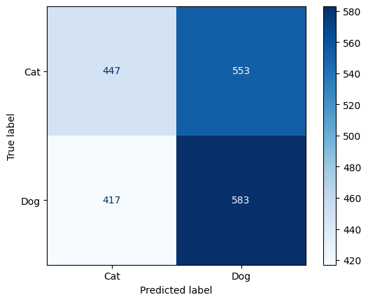

```
Fine-Tuned VGG16 Performance:
              precision    recall  f1-score   support

         Cat       0.50      0.51      0.51      1000
         Dog       0.50      0.49      0.50      1000

    accuracy                           0.50      2000
   macro avg       0.50      0.50      0.50      2000
weighted avg       0.50      0.50      0.50      2000
```

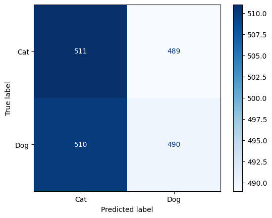

```python
from sklearn.metrics import classification_report, confusion_matrix, ConfusionMatrixDisplay
import numpy as np

def evaluate_model(model, test_dataset):
    predictions = model.predict(test_dataset)
    predictions = np.round(predictions).astype(int)
    true_labels = np.concatenate([y for x, y in test_dataset])

    print(classification_report(true_labels, predictions, target_names=["Cat", "Dog"]))

    cm = confusion_matrix(true_labels, predictions)
    disp = ConfusionMatrixDisplay(confusion_matrix=cm, display_labels=["Cat", "Dog"])
    disp.plot(cmap=plt.cm.Blues)
    plt.show()

print("Vanilla CNN Performance:")
evaluate_model(vanilla_cnn_model, test_dataset)

print("Fine-Tuned VGG16 Performance:")
evaluate_model(finetuned_vgg16_model, test_dataset)
```

### Visualize the precision-recall tradeoff for both models.

```
Vanilla CNN Precision-Recall Curve:
```

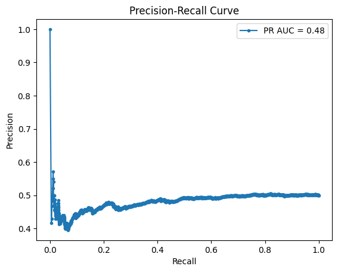

```
Fine-Tuned VGG16 Precision-Recall Curve:
```

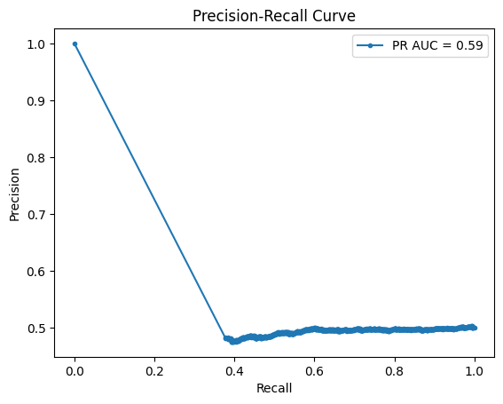

```python
from sklearn.metrics import precision_recall_curve, auc

def plot_precision_recall_curve(model, test_dataset):
    true_labels = np.concatenate([y for x, y in test_dataset])
    predictions = model.predict(test_dataset).flatten()

    precision, recall, _ = precision_recall_curve(true_labels, predictions)
    pr_auc = auc(recall, precision)

    plt.plot(recall, precision, marker=".", label=f"PR AUC = {pr_auc:.2f}")
    plt.xlabel("Recall")
    plt.ylabel("Precision")
    plt.title("Precision-Recall Curve")
    plt.legend()
    plt.show()

print("Vanilla CNN Precision-Recall Curve:")
plot_precision_recall_curve(vanilla_cnn_model, test_dataset)

print("Fine-Tuned VGG16 Precision-Recall Curve:")
plot_precision_recall_curve(finetuned_vgg16_model, test_dataset)
```

### Display specific examples where the model made incorrect predictions to understand weaknesses.

```
Vanilla CNN Failure Cases:
Number of incorrect predictions: 976
```

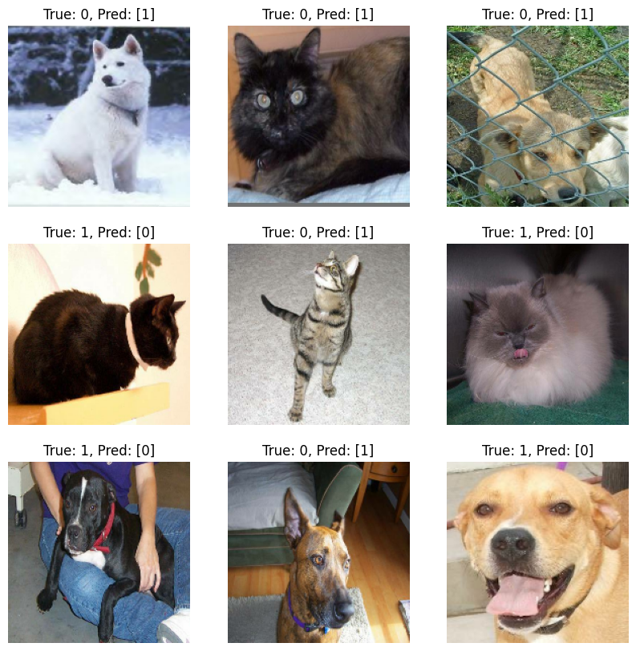

```
Fine-Tuned VGG16 Failure Cases:
Number of incorrect predictions: 1001
```

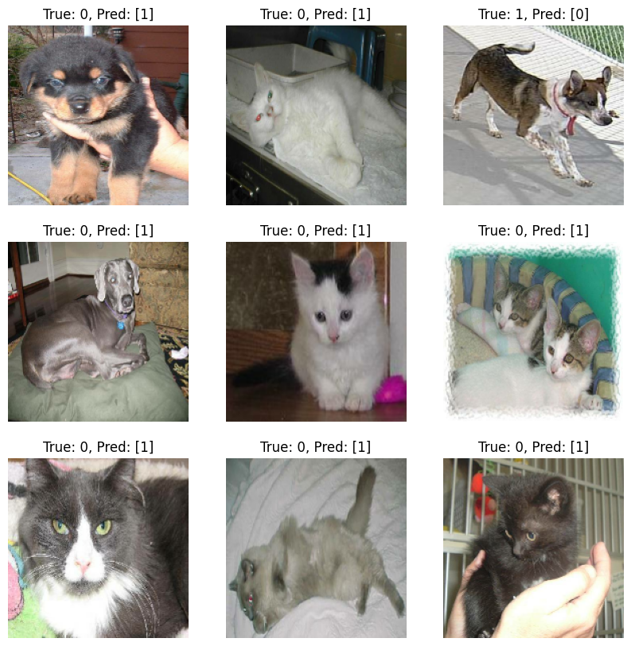

```python
def display_failure_cases(model, test_dataset):
    predictions = model.predict(test_dataset)
    predictions = np.round(predictions).astype(int)
    true_labels = np.concatenate([y for x, y in test_dataset])
    images = np.concatenate([x for x, y in test_dataset])

    incorrect_indices = np.where(predictions.flatten() != true_labels)[0]
    print(f"Number of incorrect predictions: {len(incorrect_indices)}")

    plt.figure(figsize=(10, 10))
    for i, idx in enumerate(incorrect_indices[:9]):
        ax = plt.subplot(3, 3, i + 1)
        plt.imshow(images[idx].astype("uint8"))
        plt.title(f"True: {true_labels[idx]}, Pred: {predictions[idx]}")
        plt.axis("off")
    plt.show()

print("Vanilla CNN Failure Cases:")
display_failure_cases(vanilla_cnn_model, test_dataset)

print("Fine-Tuned VGG16 Failure Cases:")
display_failure_cases(finetuned_vgg16_model, test_dataset)
```